# 04 - R framework with IMPACT - session 4

Author

Yann Say

Published

October 7, 2024

# Recap

```r
library(analysistools)
library(dplyr)

my_data <- analysistools::analysistools_MSNA_template_data

sampling_frame <- data.frame(
  strata = c("admin1a", "admin1b", "admin1c"),
  population = c(100000, 200000, 300000)
)

my_data <- my_data %>%
  add_weights(sampling_frame, "admin1", "strata", "population")

my_loa <- analysistools::analysistools_MSNA_template_loa

my_design <- srvyr::as_survey_design(my_data, weights = "weights", strata = "admin1")
my_results <- create_analysis(my_design, loa = my_loa, sm_separator = "/")
```

# Outputs - Wide tables

```r
library(presentresults)

my_results_table <- my_results$results_table
```

The framework is built around 4 steps: cleaning, composition, analysis, outputs

- *Cleaning*: Any manipulation to go from the raw data to the clean data
- *Composition*: Any manipulation before the analysis e.g. adding indicators, adding information from loop, main dataset, or any other dataset (e.g. previous round), aok aggregation, etc.
- *Analysis*: Any manipulation regarding only the analysis.
- *Outputs*: Any manipulation to format the outputs. Outputs are created from the results table, from the stat + analysis key

The following section will present some introduction about the outputs.

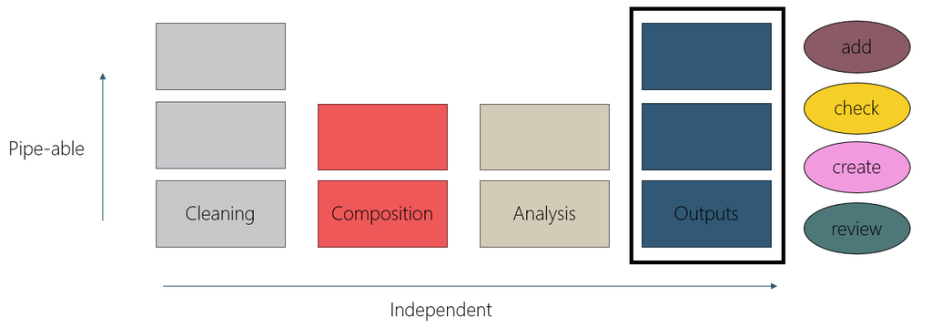

There are currently two types of table:

- one that have the variables in the rows and the disagregation in the columns,
- one that have the disagregation in the rows and the variables in the columns.

There are two steps to turn a results table:

- Turn the long results table to a large results table.
- Format and export it to Excel.

**create_**

**create_*** functions will create, transform something, e.g. creating a cleaning log with the checks to be filled, create analysis results table, create an output.

Outputs from **create_*** functions outputs can be in different shape, format, etc.

**create_*** function is catch-all.

## create_*_group_x_variable

Wide table with the groups in the rows and the variables in the columns.

```r
my_results_table %>%
  create_table_group_x_variable() %>%
  create_xlsx_group_x_variable(file_path = "outputs/04 - example - group_x_variable.xlsx", overwrite = T)
```

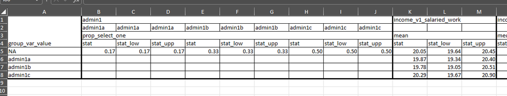

## create_*_variable_x_group

Wide table with the variables in the rows and the groups in the columns.

```r
my_results_table %>%
  create_table_variable_x_group() %>%
  create_xlsx_variable_x_group(file_path = "outputs/05 - example - variable_x_group.xlsx", overwrite = T)
```

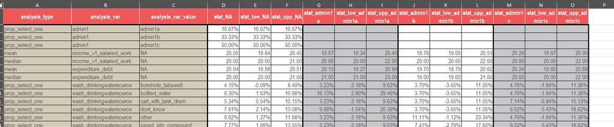

# Outputs - Tabular HTML

The folders *05 - reach_tabular_html_** are example of Quarto projects. They can be used to produce some tables in the html format.

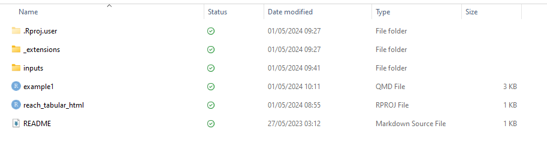

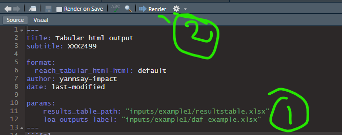

The params in the header can be change. Use *Render* after to create the html output.

[figure not shown]

**Note**

**The following is work in progress.** It will later become something like *create_html_variable_x_group*.

# Exercise

## Exercise 1

- Create an excel table with the strata in the rows and the variables in the columns.

```r
library(presentresults)
```

```r
exercise_outputs <- readxl::read_excel("inputs/10 - exercise - analysis_to_review.xlsx")
```

**Expand to get the answer**

```r
exercise_outputs %>%
  create_table_group_x_variable() %>%
  create_xlsx_group_x_variable(file_path = "outputs/06 - correction - group_x_variable_table.xlsx", overwrite = T)
```

## Exercise 2

- Try the tabular html output.
- Try to edit the authors, RCID and the introduction.